# Vulnerabilidad_SE

**Vulnerabilidad socioeconómica**

#### Resumen

*La mayoría de la información requerida para el cálculo de vulnerabilidad socioeconómica la obtuvimos del censo de población y vivienda 2020, a excepción del área de los AGEBs la cual se calculó con el software Qgis 3.10.10. Para poder utilizar la base de datos en r y poder hacer más óptimo el procedimiento se exporto la tabla de atributos con la información de clave del ageb y el área total en formato dbf, posteriormente se convirtió en csv para finalmente importar la base de datos en r y adjuntar la base de datos de censo de población y vivienda. Finalmente, se realizaron los cálculos necesarios para obtener los 13 parámetros para el cálculo de la vulnerabilidad socioeconómica y poder hacer su representación mediante un mapa.*

**Las bases de datos empladas en este codigo estan disponibles para su reproducción**

### Flujo de trabajo en Qgis

#### Objetivo:

El objetivo de este procesamiento es obtener una base de datos con una clave única para cada AGEB y el área que ocupan en km², para posteriormente unirla con la base de datos que contiene los demás parámetros para el cálculo de vulnerabilidad socioeconómica. Es indispensable esta clave unica ya que algunas claves de AGEB se repiten en diferentes municipios lo cual puede generar confusion a el momento de unir la base de datos.

#### Insumos:

La capa de ageb se obtuvo del marco geoestadístico [INEGI,2020](https://www.inegi.org.mx/temas/mg/#Descargas).

### Diagrama de Flujo

[figure not shown]

##### Procesamiento:

Abrimos la capa AGEB en Qgis 3.10.10.

Para generar la clave única esta debe de coincidir con la clave de nuestra otra base de datos, por esta razón es necesario quitar le los ceros a los campos CVE_MUN y CVE_LOC:

- Crear un campo temporal:

  ```
       En type colocamos: Short Integer<br>
       Dar clic en ok <br>
       En la sección de name colocamos: Num <br>
  ```

- Homogenizar los campos necesarios con los de la otra base de datos

> En la tabla de atributos nos dirigimos al campo que acabamos de crear en la parte superior donde está escrito el nombre del campo damos clic con botón derecho --> Field Calculator. Una vez desplegada la ventana de la calculadora de campos colocamos [CVE_LOC], damos clic en ok. Esto nos quitara los ceros de la izquierda. Almacenaremos esta información en el campo original, para ello en la parte superior que tiene el nombre de campo damos clic con botón derecho --> Field Calculator y colocamos [Num], damos clic en ok.

> Para el campo CVE_MUN hacemos el mismo procedimiento nos dirigimos a el campo NUM y damos clic con botón derecho posteriormente damos clic en Field Calculator y en la ventana que se despliega ponemos [CVE_MUN] y damos clic en ok. Nos dirigimos a el campo CVE_MUN hacemos clic derecho en el nombre del campo y posteriormente en Field Calculator una vez desplegada la ventana de la calculadora de campos colocamos [Num] y damos clic en ok. Borrar campos innecesarios

> Vamos a agregar ceros en el campo CVE_AGEB para que coincida con la clave de nuestra otra base de datos. En la otra base de datos los registros de AGEB tienen todos 4 dígitos lo cual homogeniza el número de caracteres de cada AGEB. Por lo anterior es necesario agregar ceros a la izquierda de los números, para aquellos registros que solo tengan dos dígitos o tres dígitos por lo que procedemos a dar clic con botón derecho en el nombre del campo AGEB, abrimos la calculadora de campos y seleccionamos los registros con tres múltiplos damos clic con botón derecho y colocamos lo siguiente "0"+[CVE_AGEB], luego realizamos un procedimiento similar para aquellos registros que tienen dos dígitos, damos clic derecho en el nombre del campo y abrimos la calculadora de campos donde colocamos la siguiente expresión "00"+[CVE_AGEB].
- Borrar campos innecesarios

### Flujo de trabajo en R

#### Objetivo

1.- Unir la base de datos con los parámetros de población del censo 2020 con el área de los AGEBs  
2.- Obtener los 13 parámetros necesarios para el calculo de la vulnerabilidad socieconómica  
3.- Calcular 13 indicadores de vulnerabilidad socieconómica  
4.- Calcular la vulnerabilidad socieconómica total  
5.- Obtener una base de datos en formato .csv con la información de vulnerabilidad socieconómica total

#### Insumos

Como insumos se utilizara la base de datos de poblacion y vivenda (INEGI, 2020) la cual fue previamente limpiada y la base de datos obtenida anteriormente, la cual contiene la información de clave del AGEB y area que ocupa cada AGEB en km^2.

#### Consideraciones y operaciones para obtener cada parámetro

Primero se identificaron en nuestras dos bases de datos los campos necesacrios para realizar el analisis de vulnerabilidad socioeconómica, en la siguiente tabla podemos identificar los campos utilizados para cada indicador.

| Indicador | Nombre del indicador | Clave INEGI |
| --- | --- | --- |
| VSE1 | Población con discapacidad | PCON_DISC, PCON_LIMI |
| VSE2 | Densidad de población | POBTOT, AREA* |
| VSE3 | Porcentaje de población no derechohabiente | PSINDER |
| VSE4 | Razón de dependencia | PE_INAC, PEA |
| VSE5 | Hogares con jefatura femenina | PHOGJEF_F |
| VSE6 | Hacinamiento (Número de habitantes / cuartos de la vivienda) | PROM_OCUP |
| VSE7 | Acceso a la información | TVIVPARHAB, VPH_SINTIC |
| VSE8 | Cuál es el nivel educativo de la población | GRAPROES |
| VSE9 | Porcentaje de la población de habla indígena | P5_HLI, POBTOT |
| VSE10 | Porcentaje de analfabetismo | P8A14AN, P15YM_AN, POBTOT |
| VSE11 | Porcentaje de viviendas que no disponen de luz eléctrica, agua entubada de la red pública y drenaje | VPH_C_SERV |
| VSE12 | Porcentaje de población de 6 a 14 años que asiste a la escuela | P_6A11, P6A11_NOA, P_12A14, P12A14NOA |
| VSE13 | Porcentaje de viviendas con piso de tierra | VPH_PISOTI, TVIVPARHAB |

##### VSE1 .- Población con discapacidad:

Este idicador se obtuvo mediante la suma de dos párametros; personas discapasidad y limitación. A continuacion se describe brevemente cada uno:

> 1.-Población con discapacidad: en este parámetro se consideran personas que realizan con mucha dificultad o no pueden hacer al menos una de las siguientes actividades: ver, aun usando lentes; oír aun usando aparato auditivo; caminar, subir o bajar; recordar o concentrarse; bañarse, vestirse o comer; hablar o comunicarse. La clave con la que se identifica el campo es PCON_DISC.

> 2.-Población con limitación: este parámetro hace referencia a personas que realizan con poca dificultad al menos una de las siguientes actividades: ver, aun usando lentes; oír aun usando aparato auditivo; caminar, subir o bajar; recordar o concentrarse; bañarse, vestirse o comer; hablar o comunicarse. La clave del parámetro es PCON_LIMI.

##### VSE2 .- Densidad de población

Este indicador se obtuvo dividiendo la población total (INEGI,2020) entre el area decada AGEB:

> 1.- Población total: Total de personas que residen habitualmente en el país, la entidad federativa, el municipio o la demarcación territorial y la localidad. Incluye la estimación del número de personas en viviendas particulares sin información de ocupantes. Incluye a la población que no especificó su edad. La clave del parámetro es POBTOT

##### VSE4 .- Razón de dependencia

```
El indicador se calcula como:
RD = (PobDep/ PobProd) X 100, donde
RD = razón de dependencia,
PobDep = población dependiente
PobProd = población en edad productiva entre 12 años.y más
```

> La población dependiente se refiere a población de 12 años y más no económicamente activa, en esta categoría se incluyen Personas de 12 años y más pensionadas o jubiladas, estudiantes, dedicadas a los quehaceres del hogar; que tienen alguna limitación física o mental permanente que les impide trabajar; o realizan otras actividades no económicas. La clave de este parámetro en el INEGI es PE_INAC

> Población de 12 años y más económicamente activa en este parámetro se consideran Personas de 12 años y más que trabajaron, tenían trabajo pero no trabajaron o buscaron trabajo en la semana de referencia. La clave con la que se identifica en el INEGI es PEA.

##### VSE5 .- Hogares con jefatura femenina

> Para este indicador no fue necesario hacer ningún cálculo el parámetro utilizado fue población en hogares censales con persona de referencia mujer la cual la describen como personas en hogares censales donde la persona de referencia es mujer. Se considera un hogar en cada vivienda particular. Incluye casa única en el terreno; casa que comparte terreno con otra(s); casa dúplex; departamento en edificio; vivienda en vecindad o cuartería; vivienda en cuarto de azotea; local no construido para habitación; vivienda móvil; refugio y no especificado de vivienda particular. Y la clave del INEGI con la que se distingue es PHOGJEF_F

##### VSE6 .- Hacinamiento (Número de habitantes / cuartos de la vivienda)

> Este indicador se tomo directamente de la base de datos del INEGI, el parámetro hace referencia a el promedio de ocupantes en viviendas particulares habitadas. Y las caracterirsticas son Resultado de dividir el número de personas que residen en viviendas particulares habitadas, entre el número de esas viviendas.La clave en la base de datos del INEGI es PROM_OCUP.

##### VSE7 .- Acceso a la información

> El indice se calculo restando el total de viviendas particulares habitadas en la cual la clave es TVIVPARHAB y Viviendas particulares habitadas sin tecnologías de la información y de la comunicación (TIC). El parámetro se describe como Viviendas particulares habitadas que no cuentan con algún aparato o dispositivo para oír radio, televisor, computadora, laptop o tablet, línea telefónica fija, teléfono celular, Internet, servicio de televisión de paga (cable, satelital), servicio de películas, música o videos de paga por internet ni consola de videojuegos. Comprende las viviendas particulares para las que se captaron las características de la vivienda, clasificadas como: casa única en el terreno; casa que comparte terreno con otra(s); casa dúplex; departamento en edificio; vivienda en vecindad o cuartería; vivienda en cuarto de azotea de un edificio y no especificado de vivienda particular. Incluye a las viviendas particulares sin información de ocupantes. La clave de la base de datos es VPH_SINTIC

##### VSE8 .- Nivel educativo de la población

> Para este indicador no se hizo ningun calculo se tomo el parámetro grado promedio de escolaridad este parámetro hace referencia a Resultado de dividir el monto de grados escolares aprobados por las personas de 15 a 130 años de edad entre las personas del mismo grupo de edad. Excluye a las personas que no especificaron los grados aprobados y la clave asociada es GRAPROES

##### VSE9 .- Porcentaje de la población de habla indígena

Para este prámetro se calculo el porcentaje de población indigena utilizando los siguientes campos:

> *Población de 5 años y más que habla alguna lengua indígena, se tomo encuenta este parámetro ya que se considero que a partir de los 5 años los niños ya tienen una buena dicción la clave de este parametro es P5_HLI

> *Población total, toma encuenta el total de personas que residen habitualmente en el país, la entidad federativa, el municipio o la demarcación territorial y la localidad. Incluye la estimación del número de personas en viviendas particulares sin información de ocupantes. Incluye a la población que no especificó su edad. La clave en la base de datos del INEGI es POBTOT

##### VSE10 .- Porcentaje de analfabetismo

Para este prámetro se calculo el porcentaje de analfabetismo utilizando los siguientes campos:

> *Población total, toma encuenta el total de personas que residen habitualmente en el país, la entidad federativa, el municipio o la demarcación territorial y la localidad. Incluye la estimación del número de personas en viviendas particulares sin información de ocupantes. Incluye a la población que no especificó su edad. La clave en la base de datos del INEGI es POBTOT

> Se considero a poblacion mayor de 8 años, tomando encuenta que los niños aprenden a leer y escribir entre los 6 y 7 años. Así que fue necesario tomar encuenta dos campos , población de 8 a 14 años que no sabe leer y escribir con clave P8A14AN y población de 15 años y más analfabeta con clave P15YM_AN. La suma de estos dos campos da como resultado el total de población con analfabetismo de 8 años y más.

##### VSE11 .- Porcentaje de viviendas que no disponen de luz eléctrica, agua entubada de la red pública y drenaje

Para este prámetro se calculo el porcentaje de de viviendas que no disponen de luz eléctrica, agua entubada de la red pública y drenaje utilizando los siguientes parámetros:

> - Para calcular este porcentaje se utlizo el siguiente campo Viviendas particulares habitadas que disponen de energía eléctrica, agua entubada de la red pública y drenaje con clave VPH_C_SERV
> - Total de viviendas particulares habitadas las cuales toman encuenta Viviendas particulares habitadas de cualquier clase: casa única en el terreno; casa que comparte terreno con otra(s); casa dúplex; departamento en edificio; vivienda en vecindad o cuartería; vivienda en cuarto de azotea de un edificio; local no construido para habitación, vivienda móvil; refugio y no especificado de vivienda particular. Incluye a las viviendas particulares sin información de ocupantes y la clave es TVIVPARHAB

##### VSE12 .-Porcentaje de población de 6 a 14 años que asiste a la escuela

> Para este índice se calculo el total de población entre 6 y 14 años, para ello se sumaron dos campos; Población de 6 a 11 años con clave P_6A11 y población de 12 a 14 años con clave P_12A14. Posteriormente se calculo la población que no asiste a la escuela, se realizo la suma de dos campos; población de 6 a 11 años que no asiste a la escuela con clave P6A11_NOA y población de 12 a 14 años que no asiste a la escuela con clave P12A14NOA. Para calcular el total de población que asiste a la escuela a la poblacion total entre y 14 años se le resto el total de pblacion que no asiste a la escuela. Una vez obtenido este valor se procedio a calcular el porcentaje de la poblacion que asiste a la escuela.

##### VSE13 .-Porcentaje de viviendas con piso de tierra

> Se calculo el porcentaje de viviendas con piso de tierra usando el parámetro Viviendas particulares habitadas con piso de tierra, en el cual se incluyen Viviendas particulares habitadas con piso de tierra. Comprende las viviendas particulares para las que se captaron las características de la vivienda, clasificadas como: casa única en el terreno; casa que comparte terreno con otra(s); casa dúplex; departamento en edificio; vivienda en vecindad o cuartería; vivienda en cuarto de azotea de un edificio y no especificado de vivienda particular. Incluye a las viviendas particulares sin información de ocupantes y tiene como clave VPH_PISOTI. Además se ulitizó el parámetro total de viviendas particulares habitadas, en el cual se consideraron Viviendas particulares habitadas de cualquier clase: casa única en el terreno; casa que comparte terreno con otra(s); casa dúplex; departamento en edificio; vivienda en vecindad o cuartería; vivienda en cuarto de azotea de un edificio; local no construido para habitación, vivienda móvil; refugio y no especificado de vivienda particular. Incluye a las viviendas particulares sin información de ocupantes y tiene como clave TVIVPARHAB.

### Diagrama de flujo

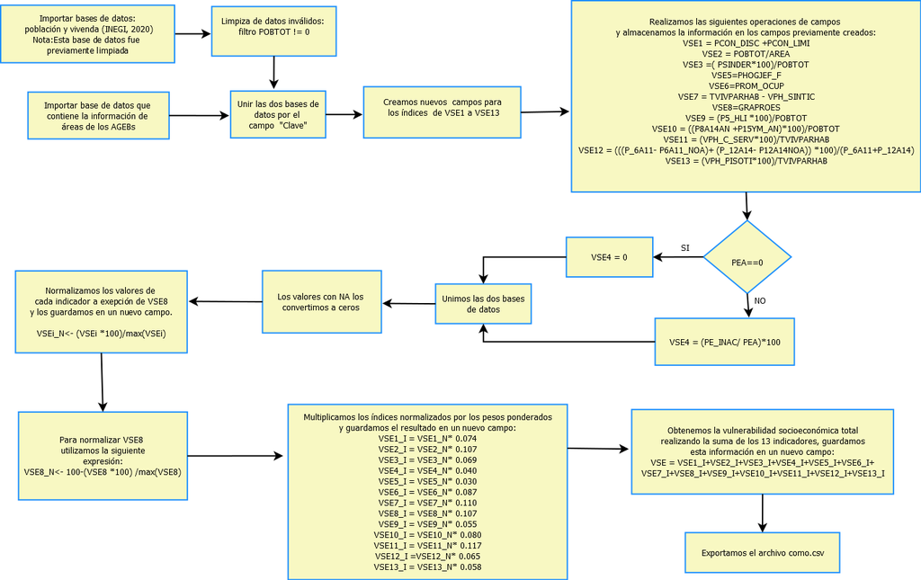

### Codígo para calcular los indicadores en R

```python
getwd()

dir()

library(dplyr)

library(readxl)

####IMPORTAR LAS BASES DE DATOS
poblacion <- read.csv("POBLACION_AGEB.csv", header = TRUE )
AGEB_AREA <- read.csv("DATOS_AGEB.csv", header = TRUE )
summary(poblacion)

### Hacemos un filtro y quitamos los valores de los ageb con población= 0 y poblacion activa diferente de cero

poblacion<- poblacion %>% filter(POBTOT!=0)

poblacion$PE_INACT
View(poblacion)

### Unimos las tablas
datos_union<- merge(poblacion, AGEB_AREA, by="Clave")

str(poblacion)

###CREAMOS UN NUEVO CAMPO EN DONDE CALCULAREMOS EL PARAMETRO VSE1 : Población con discapacidad
datos_union$VSE1 = datos_union$PCON_DISC + datos_union$PCON_LIMI
names(datos_union)


###CREAMOS UN NUEVO CAMPO EN DONDE CALCULAREMOS EL PARAMETRO VSE2 : Densidad de población
##Dividimos la población total entre el área del AGEB

datos_union$VSE2 = datos_union$POBTOT/ datos_union$AREA_KM


####Porcentaje de población no derechohabiente
datos_union$VSE3 = (datos_union$PSINDER*100)/datos_union$POBTOT


datos_union$VSE5<- datos_union$PHOGJEF_F
datos_union$VSE6<- datos_union$PROM_OCUP


##CREAMOS UN NUEVO CAMPO EN DONDE CALCULAREMOS EL PARAMETRO VSE7: 	Acceso a la información

datos_union$VSE7 = datos_union$TVIVPARHAB - datos_union$VPH_SINTIC

datos_union$VSE8<- datos_union$GRAPROES



### porcentaje de población de habla indigena VSE9


datos_union$VSE9 = (datos_union$P5_HLI *100)/datos_union$POBTOT


summary(datos_union)

### porcentaje de analfabetismo VSE10

datos_union$VSE10 = ((datos_union$P8A14AN +datos_union$ P15YM_AN)*100)/datos_union$POBTOT


##Porcentaje de viviendas que no disponen de luz eléctrica, agua entubada de la red pública y drenaje: VSE11

datos_union$VSE11 = (datos_union$VPH_C_SERV*100)/datos_union$TVIVPARHAB

### Porcentaje de población de 6 a 14 años que asiste a la escuela : VSE12

datos_union$VSE12 = (((datos_union$P_6A11- datos_union$P6A11_NOA)+ (datos_union$P_12A14- datos_union$P12A14NOA)) *100)/(datos_union$P_6A11+ datos_union$P_12A14)


##Porcentaje de viviendas con piso de tierra

datos_union$VSE13 = (datos_union$VPH_PISOTI*100)/datos_union$TVIVPARHAB

##CREAMOS UN NUEVO CAMPO EN DONDE CALCULAREMOS EL PARAMETRO VSE4 : Razon de dependencia
datos_df_cero<- datos_union %>% filter(PEA!=0)
datos_cero<- datos_union %>% filter(PEA==0)

#calculamos el parametro vse4 para la poblacion que tiene información de poblacion no dependiente
datos_df_cero$VSE4 <- (datos_df_cero$PE_INAC/ datos_df_cero$PEA)*100
#Para los registros  que no tienen informacion de poblacion no dependiente asignamos cero al valor de este indice
datos_cero$VSE4 <- 0

summary(datos_cero)

##Unimos los regisrtros de las dos bases de datos

datos<-rbind(datos_df_cero, datos_cero)
```

Se normalizaron los valores con referencia a los valores máximos de cada campo, así, el valor de cada una de las AGEB representaría un porcentaje del valor máximo obtenido. Para ello se multiplico El valor de cada índice por 100 y se dividio entre el vaolor maximo del indice. En la siguiente tabla se observan los valores maximos calculados para cada indice. Para el índice VSE8 ya que la vulnerabilidad es inversamente proporcional a la escolaridad los valores de este índice se trataron de la siguiente manera: 100-(VSE8 *100)/max(VSE8)

| Indicador | Maximo |
| --- | --- |
| VSE1 | 2581.0 |
| VSE2 | 41.15881 |
| VSE3 | 100.00 |
| VSE4 | 615.79 |
| VSE5 | 5554 |
| VSE6 | 7.670 |
| VSE7 | 4629 |
| VSE8 | 17.67 |
| VSE9 | 66.66667 |
| VSE10 | 46.667 |
| VSE11 | 100.00 |
| VSE12 | 100.00 |
| VSE13 | 100.00 |

Una vez normalizados los datos se procedio a multiplicar el valor de los índices normalizado por la ponderacion de cada indicador, en la siguiente tabla se muestran los pesos ponderados para cada indicador

| Clave del indicador | Indicador | Ponderación |
| --- | --- | --- |
| VSE1 | Población con discapacidad | 0.074 |
| VSE2 | Densidad de población | 0.107 |
| VSE3 | Porcentaje de población no derechohabiente | 0.069 |
| VSE4 | Razón de dependencia | 0.040 |
| VSE5 | Hogares con jefatura femenina | 0.030 |
| VSE6 | Hacinamiento (Número de habitantes / cuartos de la vivienda) | 0.087 |
| VSE7 | Acceso a la información | 0.110 |
| VSE8 | Cuál es el nivel educativo de la población | 0.107 |
| VSE9 | Porcentaje de la población de habla indígena | 0.055 |
| VSE10 | Porcentaje de analfabetismo | 0.080 |
| VSE11 | Porcentaje de viviendas que no disponen de luz eléctrica, agua entubada de la red pública y drenaje | 0.117 |
| VSE12 | Porcentaje de población de 6 a 14 años que asiste a la escuela | 0.065 |
| VSE13 | Porcentaje de viviendas con piso de tierra | 0.058 |

Finalmente para obtener la vulnerabilidad socioecónomica total se sumaron los 13 indicadores anteriores, a continuacion se presenta el código de el calculo de la normalización de los índices así como el calculo para la vulnerabilidad sosioeconómica total

```python
# SUSTITUIMOS na por cero
datos[is.na(datos)] <- 0

##NORMALIZAMOS LOS DATOS MULTIPLICANDO POR 100 Y DIVDIENDO LO ENTRE EN  VALOR MAXIMO DE CADA INDICADOR
datos$VSE1_N<- (datos$VSE1 *100)/max(datos$VSE1)
datos$VSE2_N<- (datos$VSE2 *100)/max(datos$VSE2)
datos$VSE3_N<- (datos$VSE3 *100)/max(datos$VSE3)
datos$VSE4_N<- (datos$VSE4 *100)/max(datos$VSE4)
datos$VSE5_N<- (datos$VSE5 *100)/max(datos$VSE5)
datos$VSE6_N<- (datos$VSE6 *100)/max(datos$VSE6)
datos$VSE7_N<- (datos$VSE7 *100)/max(datos$VSE7)
datos$VSE8_N<- 100-(datos$VSE8 *100)/max(datos$VSE8)
datos$VSE9_N<- (datos$VSE9 *100)/max(datos$VSE9)
datos$VSE10_N<- (datos$VSE10 *100)/max(datos$VSE10)
datos$VSE11_N<- (datos$VSE11 *100)/max(datos$VSE11)
datos$VSE12_N<- (datos$VSE12 *100)/max(datos$VSE12)
datos$VSE13_N<- (datos$VSE13 *100)/max(datos$VSE13)

summary(datos)
View(datos)
#obtener el valor ponderado del indicador, se multiplicaron los valores
#normalizados por la ponderación correspondiente a cada indicador

datos$VSE1_I <- datos$VSE1_N* 0.074
datos$VSE2_I <- datos$VSE2_N* 0.107
datos$VSE3_I <- datos$VSE3_N* 0.069
datos$VSE4_I <- datos$VSE4_N* 0.040
datos$VSE5_I <- datos$VSE5_N* 0.030
datos$VSE6_I <- datos$VSE6_N* 0.087
datos$VSE7_I <- datos$VSE7_N* 0.110
datos$VSE8_I <- datos$VSE8_N* 0.107
datos$VSE9_I <- datos$VSE9_N* 0.055
datos$VSE10_I <- datos$VSE10_N* 0.080
datos$VSE11_I <- datos$VSE11_N* 0.117
datos$VSE12_I <- datos$VSE12_N* 0.065
datos$VSE13_I <- datos$VSE13_N* 0.058
##Calculamos el valor de la vulnerabilidad socioeconomica sumando el valor de los indices
datos$VSE <- datos$VSE1_I+datos$VSE2_I +datos$VSE3_I+datos$VSE4_I+datos$VSE5_I+datos$VSE6_I+datos$VSE7_I+datos$VSE8_I+
  datos$VSE9_I+datos$VSE10_I+datos$VSE11_I+datos$VSE12_I+datos$VSE13_I


summary(datos)


##Exportamos la base de datos


write.csv(datos, file="Vulnerabilidad_SE_completa.csv")

datos_sig <- data.frame(CLAVE=datos$Clave,  N_MZA=datos$N_MZ, POBTOT=datos$POBTOT, AREA=datos$AREA_KM, VSE=datos$VSE)
write.csv(datos_sig, file="Vulnerabilidad_SE_SIG_2.csv")
```

### Mapa de vulnerabilidad socioeconómica

#### Objetivo

Generar un mapa de vulnerabilidad socioeconómica por AGEB

#### insumos

1.- Base de datos con la información de vulnerabilidad socioeconómica y clave única para cada AGEB  
2.- Capa de AGEBs con clave única para cara AGEB

#### Diagrama de flujo

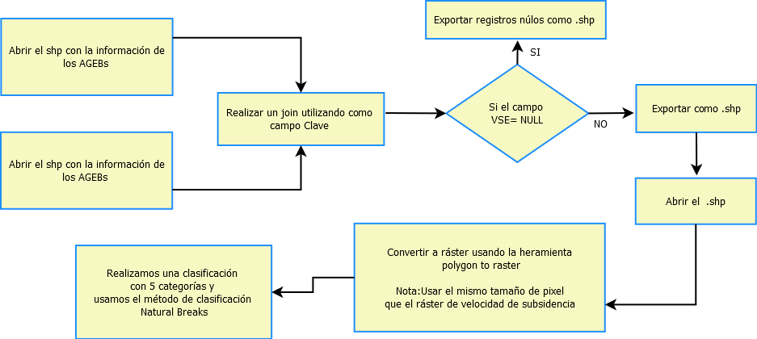

#### Procesamiento

1.-Abrimos la base de la base de datos con la información de vulnerabilidad socieconómica y el shp con la información de AGEBs en Arcgis 10.5  
2.- Damos clic con botón derecho sobre la capa de AGEBs y nos dirigimos a join and relates --> join. Colocamos los siguiente en los parámetros:

```
* What do you want to join to this layer?

         Join attributes from table

* Choose the fiel in this layer that the join will be based on:

         Clave

* Choose the table to join to this layer, or load the table from disk:

         Seleccionar la base de datos con la información de vulnerabilidad socieconómica

* Choose de fiel in the table to base the join on:

         Clave

* Seleccionar la opcción:

        Keep all records
```

3.- Abrimos la tabla de atributos y seleccionamos los registros que tengan valores nulos dalos clic en el paner de capas y exportamos los registros nulos en un nuevo shp

4.- En la tabla de atributos seleccionamos el botón de invertir selección posteriormente nos dirigimos al paner de capas damos clic con botón derecho sobre nuestra capa y exportamos el archivo con formato .shp

5.- Nos dirigimos a ArcToolbox desplegamos el menú Conversion Tools posteriormente nos dirigimos a la opcción To Raster y damos clic en Polygon to Raster como parámetros colocamos lo siguiente:

```
* Input Features
         Colocar la capa exportada en el punto 4
* Value field
          "VSE"
* Output Raster Dataset
         Colocar la rúta de salida
* Cell assignment type:
         CELL_CENTER
* Priority fiel
         NONE
* Cell size:
          0.001328
```

6.- Abrimos el tiff que acabamos de crear damos clic con bón derecho y nos dirigimos a propiedades posteriormente damos clic en la pestaña simbology y en show damos clic en classified, seleccionamos 5 clases y dejamos como automático el método de clasificación Natural Breaks (Jenks), damos clic en Aceptar

Al final obtenemos la siguiente clasificación para la vulnerabilidad socioeconómica

| Clasificación | Rango | Vulnerabilidad |
| --- | --- | --- |
| 1 | 5.11-18.98 | Muy baja |
| 2 | 18.99 - 29.77 | Baja |
| 3 | 29.78 - 34.20 | Media |
| 4 | 34.21 - 38.83 | Alta |
| 5 | 38.84 - 54.24 | Muy alta |